# Advanced Training

## Table of Contents

1. Introduction
2. Setup
3. Helper Functions
4. Data
5. Model
6. Training  
   6.1. Basic Training  
   6.2. Several metrics  
   6.3. Several metrics with Torchmetrics  
   6.4. Tracking history  
   6.5. Early Stopping  
   6.6. Learning Rate Scheduler
7. Annex  
   A. A reminder about val and test sets  
   B. About loss.item() and different batch sizes  
   C. Training in detail
8. References

## 1. Introduction

This notebook demonstrates how to build a complete training pipeline in PyTorch, starting from the fundamentals and progressively integrating advanced components. The goal is to create a flexible and reusable framework suitable for a variety of deep learning tasks.

We start with a minimal training loop and then incrementally add:

✅ Multiple evaluation metrics (e.g., accuracy, precision)

📉 Loss tracking and logging

🛑 Early stopping to prevent overfitting

📈 Learning rate scheduling for improved convergence

## 2. Setup

```python
import torch
import torch.nn as nn
from torch.utils.data import DataLoader

import matplotlib.pyplot as plt
from sklearn.decomposition import PCA
from sklearn.manifold import TSNE
```

```python
device = torch.device("cuda" if torch.cuda.is_available() else "cpu")
```

## 3. Helper Functions

```python
# --- Plot data ---
def plot_data(X_train, X_val, X_test, y_train, y_val, y_test):
    # Concatenate full dataset to plot
    X_all = torch.cat([X_train, X_val, X_test]).numpy()
    y_all = torch.cat([y_train, y_val, y_test]).numpy()

    # Choose dimensionality reduction method (PCA or TSNE)
    method = 'pca'  # or 'tsne'

    if method == 'pca':
        reducer = PCA(n_components=2)
    elif method == 'tsne':
        reducer = TSNE(n_components=2, random_state=0, perplexity=30)
    else:
        raise ValueError("Choose 'pca' or 'tsne'")

    X_2d = reducer.fit_transform(X_all)

    # Plot
    plt.figure(figsize=(8, 6))
    plt.scatter(X_2d[y_all == 0, 0], X_2d[y_all == 0, 1], alpha=0.5, label="Class 0")
    plt.scatter(X_2d[y_all == 1, 0], X_2d[y_all == 1, 1], alpha=0.5, label="Class 1")
    plt.title(f"2D visualization using {method.upper()}")
    plt.xlabel("Component 1")
    plt.ylabel("Component 2")
    plt.legend()
    plt.grid(True)
    plt.tight_layout()
    plt.show()



# --- Plot history ---
def plot_history(history):
    fig, axs = plt.subplots(1, 3, figsize=(18, 5))

    axs[0].plot(history["train_loss"], label="Train")
    axs[0].plot(history["val_loss"], label="Val")
    axs[0].set_title("Loss")
    axs[0].legend()

    if "train_accuracy" in history:
        axs[1].plot(history["train_accuracy"], label="Train")
        axs[1].plot(history["val_accuracy"], label="Val")
        axs[1].set_title("Accuracy")
        axs[1].legend()

    if "train_precision" in history:
        axs[2].plot(history["train_precision"], label="Train")
        axs[2].plot(history["val_precision"], label="Val")
        axs[2].set_title("Precision")
        axs[2].legend()

    plt.tight_layout()
    plt.show()
```

## 4. Data

```python
from sklearn.datasets import make_classification
from sklearn.model_selection import train_test_split
from sklearn.preprocessing import StandardScaler
from torch.utils.data import TensorDataset, DataLoader


# 1. Generate synthetic data
X, y = make_classification(n_samples=1000, n_features=20, n_classes=2, random_state=0)

# 2. Split data before scaling
X_train, X_tmp, y_train, y_tmp = train_test_split(X, y, test_size=0.3, random_state=0)
X_val, X_test, y_val, y_test = train_test_split(X_tmp, y_tmp, test_size=0.5, random_state=0)

# 3. Fit scaler on training data only
scaler = StandardScaler()
X_train = scaler.fit_transform(X_train)   # Fit + transform train
X_val = scaler.transform(X_val)           # Transform val only
X_test = scaler.transform(X_test)         # Transform test only

# 4. Convert to torch tensors
X_train = torch.tensor(X_train, dtype=torch.float32)
y_train = torch.tensor(y_train, dtype=torch.long)

X_val = torch.tensor(X_val, dtype=torch.float32)
y_val = torch.tensor(y_val, dtype=torch.long)

X_test = torch.tensor(X_test, dtype=torch.float32)
y_test = torch.tensor(y_test, dtype=torch.long)

# 5. Create DataLoaders
train_loader = DataLoader(TensorDataset(X_train, y_train), batch_size=32, shuffle=True)
val_loader = DataLoader(TensorDataset(X_val, y_val), batch_size=32)
test_loader = DataLoader(TensorDataset(X_test, y_test), batch_size=32)
```

View a few examples:

```python
X_train[:3], X[:3].shape
```

```
(tensor([[-1.7490,  0.7598,  0.6365,  1.2915,  1.2887, -1.3120,  1.2748, -0.0480,
           0.2191, -0.0448,  0.3486, -0.5288, -0.7155, -0.8305, -0.1980,  0.9602,
           0.1070,  1.3413, -0.3241,  0.5221],
         [-1.0624,  2.7448, -0.7404,  0.5845,  0.3928,  0.9887,  0.1447, -2.4156,
           0.0899,  1.5462,  0.0058,  1.3553,  0.4625,  0.8703,  1.2226,  1.9633,
           1.3332,  0.1272, -1.7175,  0.1482],
         [-0.8482, -0.5136, -0.2408,  0.0614, -0.4732,  1.9116,  0.3352,  0.9002,
           0.0792,  0.5096, -1.2818,  0.3124, -1.1101, -0.0118,  0.9162, -0.0944,
          -0.1853, -0.0414,  0.1613,  1.3528]]),
 (3, 20))
```

```python
y_val[:10]
```

```
tensor([0, 0, 0, 1, 0, 0, 0, 1, 1, 1])
```

Note that the labels are integers (0 or 1).

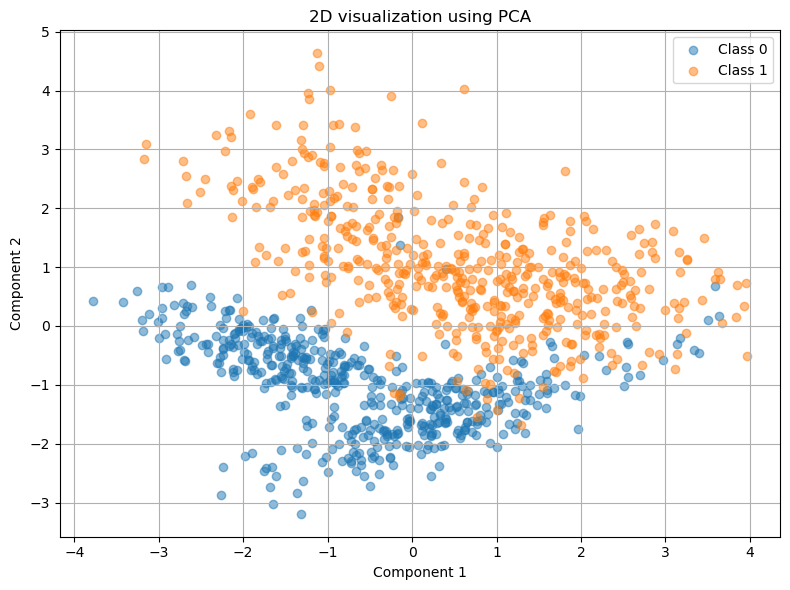

```python
plot_data(X_train, X_val, X_test, y_train, y_val, y_test)
```

## 5. Model

```python
# binary classifier
class BinaryClassifier(nn.Module):
    def __init__(self, input_dim=20, hidden=16, output_dim=2):
        super().__init__()
        self.net = nn.Sequential(
            nn.Linear(input_dim, hidden),
            nn.ReLU(),
            nn.Linear(hidden, output_dim)
        )

    def forward(self, x):
        return self.net(x)

# instantiate two separate models
#model1 = BinaryClassifier().to(DEVICE)
```

## 6. Training

### 6.1. Basic Training

```python
def train_one_epoch(model, dataloader, criterion, optimizer, device, metric_fn):
    """
    Trains the model for one epoch.

    Args:
        model (torch.nn.Module): The model to train.
        dataloader (DataLoader): DataLoader for the training data.
        criterion (callable): Loss function.
        optimizer (torch.optim.Optimizer): Optimizer for updating model weights.
        device (torch.device): Device to run computations on.
        metric_fn (callable): Metric function to evaluate performance (e.g., accuracy).
                              Should return a scalar tensor.

    Returns:
        tuple: Average loss and average metric over the epoch.
               If metric_fn is None, returns 0 for the metric.
    """
    model.train()  # Set model to training mode
    running_loss, running_metric, total_samples = 0.0, 0.0, 0

    for inputs, labels in dataloader:
        inputs, labels = inputs.to(device), labels.to(device)  # Move data to device
        optimizer.zero_grad()  # Zero gradients
        outputs = model(inputs)  # Forward pass
        loss = criterion(outputs, labels)  # Compute loss
        loss.backward()  # Backpropagation
        optimizer.step()  # Update weights

        batch_size = labels.size(0)
        running_loss += loss.item() * batch_size  # Accumulate weighted loss
        running_metric += metric_fn(outputs, labels).item() * batch_size  # Accumulate weighted metric
        total_samples += batch_size  # Track number of samples

    return running_loss / total_samples, running_metric / total_samples if metric_fn else 0
```

```python
def validate_one_epoch(model, dataloader, criterion, device, metric_fn=None):
    """
    Evaluates the model on a validation or test set for one epoch.

    Args:
        model (torch.nn.Module): The model to evaluate.
        dataloader (DataLoader): DataLoader for the validation/test data.
        criterion (callable): Loss function.
        device (torch.device): Device to run computations on.
        metric_fn (callable, optional): Metric function to evaluate performance
                                        (e.g., accuracy). Should return a scalar tensor.

    Returns:
        tuple: Average loss and average metric over the epoch.
               If metric_fn is None, returns 0 for the metric.
    """
    model.eval()  # Set model to evaluation mode
    running_loss, running_metric, total_samples = 0.0, 0.0, 0

    with torch.no_grad():  # Disable gradient tracking
        for inputs, labels in dataloader:
            inputs, labels = inputs.to(device), labels.to(device)  # Move data to device
            outputs = model(inputs)  # Forward pass
            loss = criterion(outputs, labels)  # Compute loss

            batch_size = labels.size(0)
            running_loss += loss.item() * batch_size  # Accumulate weighted loss
            running_metric += metric_fn(outputs, labels).item() * batch_size  # Accumulate weighted metric
            total_samples += batch_size  # Track number of samples

    return running_loss / total_samples, running_metric / total_samples if metric_fn else 0
```

```python
def train_model(
    model, train_loader, val_loader,
    criterion, optimizer, device,
    metric_fn, epochs=10
):

    for epoch in range(1, epochs + 1):
        train_loss, train_metric = train_one_epoch(model, train_loader, criterion, optimizer, device, metric_fn)
        val_loss, val_metric = validate_one_epoch(model, val_loader, criterion, device, metric_fn)

        print(f"Epoch {epoch:02d} | Train Loss: {train_loss:.4f}, Metric: {train_metric:.4f} | "
              f"Val Loss: {val_loss:.4f}, Metric: {val_metric:.4f}")


    return model, history
```

Let's test it:

```python
model = BinaryClassifier().to(device)
criterion = torch.nn.CrossEntropyLoss()
optimizer = torch.optim.Adam(model.parameters(), lr=0.01)

# metric
def accuracy(outputs, labels):
    preds = torch.argmax(outputs, dim=1)
    return (preds == labels).float().mean()
```

```python
# Train
model, history = train_model(
    model, train_loader, val_loader,
    criterion, optimizer, device,
    metric_fn=accuracy,
    epochs=10,
)
```

```
Epoch 01 | Train Loss: 0.5404, Metric: 0.7629 | Val Loss: 0.3142, Metric: 0.9400
Epoch 02 | Train Loss: 0.2185, Metric: 0.9343 | Val Loss: 0.1664, Metric: 0.9600
Epoch 03 | Train Loss: 0.1405, Metric: 0.9486 | Val Loss: 0.1531, Metric: 0.9600
Epoch 04 | Train Loss: 0.1144, Metric: 0.9600 | Val Loss: 0.1489, Metric: 0.9600
Epoch 05 | Train Loss: 0.0973, Metric: 0.9700 | Val Loss: 0.1557, Metric: 0.9467
Epoch 06 | Train Loss: 0.0856, Metric: 0.9786 | Val Loss: 0.1643, Metric: 0.9600
Epoch 07 | Train Loss: 0.0762, Metric: 0.9771 | Val Loss: 0.1777, Metric: 0.9533
Epoch 08 | Train Loss: 0.0653, Metric: 0.9829 | Val Loss: 0.1977, Metric: 0.9533
Epoch 09 | Train Loss: 0.0596, Metric: 0.9857 | Val Loss: 0.2045, Metric: 0.9667
Epoch 10 | Train Loss: 0.0542, Metric: 0.9857 | Val Loss: 0.2322, Metric: 0.9600
```

```python
# Final test set evaluation (only once)
test_loss, test_metric = validate_one_epoch(model, test_loader, criterion, device, accuracy)
print(f"\nFinal Test Loss: {test_loss:.4f}, Test Metric: {test_metric:.4f}")
```

```
Final Test Loss: 0.1576, Test Metric: 0.9667
```

### 6.2. Several metrics

Let’s include support for multiple metrics.

First, let's define multiple metrics (accuracy and precision in our example).

```python
from sklearn.metrics import precision_score

# accuracy
def accuracy_fn(outputs, labels):
    preds = torch.argmax(outputs, dim=1)
    return (preds == labels).float().mean()

# precision
def precision_fn(outputs, labels):
    preds = torch.argmax(outputs, dim=1).cpu().numpy()
    labels = labels.cpu().numpy()
    return torch.tensor(precision_score(labels, preds, average='binary'))  # or 'macro'

# metrics dictionary
metrics = {
    "accuracy": accuracy_fn,
    "precision": precision_fn
}
```

Now, let's modify our functions appropiately:

```python
def train_one_epoch(model, dataloader, criterion, optimizer, device, metrics):
    model.train()
    running_loss, total_samples = 0.0, 0
    metric_totals = {name: 0.0 for name in metrics} if metrics else {}

    for inputs, labels in dataloader:
        inputs, labels = inputs.to(device), labels.to(device)
        optimizer.zero_grad()
        outputs = model(inputs)
        loss = criterion(outputs, labels)
        loss.backward()
        optimizer.step()

        batch_size = labels.size(0)
        running_loss += loss.item() * batch_size
        total_samples += batch_size

        # multiple metrics!
        for name, fn in metrics.items():
            metric_totals[name] += fn(outputs, labels).item() * batch_size

    avg_loss = running_loss / total_samples
    avg_metrics = {name: total / total_samples for name, total in metric_totals.items()}

    return avg_loss, avg_metrics
```

```python
def validate_one_epoch(model, dataloader, criterion, device, metrics=None):
    model.eval()
    running_loss, total_samples = 0.0, 0
    metric_totals = {name: 0.0 for name in metrics} if metrics else {}

    with torch.no_grad():
        for inputs, labels in dataloader:
            inputs, labels = inputs.to(device), labels.to(device)
            outputs = model(inputs)
            loss = criterion(outputs, labels)
            batch_size = labels.size(0)
            running_loss += loss.item() * batch_size
            total_samples += batch_size

            # multiple metrics
            for name, fn in metrics.items():
                metric_totals[name] += fn(outputs, labels).item() * batch_size

    avg_loss = running_loss / total_samples
    avg_metrics = {name: total / total_samples for name, total in metric_totals.items()}

    return avg_loss, avg_metrics
```

```python
def train_model(
    model, train_loader, val_loader,
    criterion, optimizer, device,
    metrics, epochs=10
):

    for epoch in range(1, epochs + 1):
        train_loss, train_metrics = train_one_epoch(model, train_loader, criterion, optimizer, device, metrics)
        val_loss, val_metrics = validate_one_epoch(model, val_loader, criterion, device, metrics)

        print(f"Epoch {epoch:02d} | Train Loss: {train_loss:.4f} | Val Loss: {val_loss:.4f}")
        for name in train_metrics:
            print(f"  Train {name}: {train_metrics[name]:.4f} | Val {name}: {val_metrics[name]:.4f}")

    return model, history
```

Let's test:

```python
model = BinaryClassifier().to(device)
criterion = torch.nn.CrossEntropyLoss()
optimizer = torch.optim.Adam(model.parameters(), lr=0.01)
```

```python
# --- 7. Run ---
trained_model, history = train_model(
    model,
    train_loader,
    val_loader,
    criterion,
    optimizer,
    device,
    metrics=metrics,
)
```

```
Epoch 01 | Train Loss: 0.5235 | Val Loss: 0.2984
  Train accuracy: 0.7600 | Val accuracy: 0.9267
  Train precision: 0.7996 | Val precision: 0.9597
Epoch 02 | Train Loss: 0.2086 | Val Loss: 0.1662
  Train accuracy: 0.9300 | Val accuracy: 0.9667
  Train precision: 0.9382 | Val precision: 0.9741
Epoch 03 | Train Loss: 0.1371 | Val Loss: 0.1604
  Train accuracy: 0.9486 | Val accuracy: 0.9600
  Train precision: 0.9414 | Val precision: 0.9741
Epoch 04 | Train Loss: 0.1145 | Val Loss: 0.1620
  Train accuracy: 0.9571 | Val accuracy: 0.9533
  Train precision: 0.9598 | Val precision: 0.9732
Epoch 05 | Train Loss: 0.1015 | Val Loss: 0.1668
  Train accuracy: 0.9714 | Val accuracy: 0.9533
  Train precision: 0.9668 | Val precision: 0.9732
Epoch 06 | Train Loss: 0.0942 | Val Loss: 0.1783
  Train accuracy: 0.9714 | Val accuracy: 0.9600
  Train precision: 0.9629 | Val precision: 0.9858
Epoch 07 | Train Loss: 0.0837 | Val Loss: 0.1740
  Train accuracy: 0.9786 | Val accuracy: 0.9667
  Train precision: 0.9772 | Val precision: 0.9858
Epoch 08 | Train Loss: 0.0755 | Val Loss: 0.1893
  Train accuracy: 0.9800 | Val accuracy: 0.9667
  Train precision: 0.9872 | Val precision: 0.9858
Epoch 09 | Train Loss: 0.0724 | Val Loss: 0.1998
  Train accuracy: 0.9800 | Val accuracy: 0.9533
  Train precision: 0.9773 | Val precision: 0.9733
Epoch 10 | Train Loss: 0.0616 | Val Loss: 0.1999
  Train accuracy: 0.9829 | Val accuracy: 0.9667
  Train precision: 0.9843 | Val precision: 0.9858
```

```python
# Final test set evaluation (only once)
test_loss, test_metrics = validate_one_epoch(model, test_loader, criterion, device, metrics)
print(f"\nFinal Test Loss: {test_loss:.4f}, Test Metric: {test_metrics['accuracy']:.4f}")
```

```
Final Test Loss: 0.1425, Test Metric: 0.9733
```

### 6.3. Several metrics with Torchmetrics

Now we will use [Torchmetrics](https://lightning.ai/docs/torchmetrics/stable/) to compute the metrics.

```python
#!pip install torchmetrics
```

```python
from torchmetrics.classification import Accuracy, Precision

num_classes = 2
is_binary = num_classes == 2

# metrics setup
metrics = {
    "accuracy": Accuracy(task="binary" if is_binary else "multiclass", num_classes=num_classes).to(device),
    "precision": Precision(task="binary" if is_binary else "multiclass", num_classes=num_classes,
                           average='macro').to(device)
}

# reset
def reset_metrics(metrics):
    for metric in metrics.values():
        metric.reset()

# compute
def compute_metrics(metrics):
    return {name: metric.compute().item() for name, metric in metrics.items()}
```

```python
def train_one_epoch(model, loader, criterion, optimizer, device, metrics):
    model.train()
    total_loss, total_samples = 0.0, 0
    reset_metrics(metrics)

    for inputs, labels in loader:
        inputs, labels = inputs.to(device), labels.to(device)
        optimizer.zero_grad()
        outputs = model(inputs)
        loss = criterion(outputs, labels)
        loss.backward()
        optimizer.step()

        total_loss += loss.item() * labels.size(0)
        total_samples += labels.size(0)

        preds = torch.argmax(outputs, dim=1)
        for metric in metrics.values():
            metric.update(preds, labels)

    avg_loss = total_loss / total_samples
    final_metrics = compute_metrics(metrics)
    return avg_loss, final_metrics
```

```python
def validate_one_epoch(model, loader, criterion, device, metrics):
    model.eval()
    total_loss, total_samples = 0.0, 0
    reset_metrics(metrics)

    with torch.no_grad():
        for inputs, labels in loader:
            inputs, labels = inputs.to(device), labels.to(device)
            outputs = model(inputs)
            loss = criterion(outputs, labels)
            total_loss += loss.item() * labels.size(0)
            total_samples += labels.size(0)

            preds = torch.argmax(outputs, dim=1)
            for metric in metrics.values():
                metric.update(preds, labels)

    avg_loss = total_loss / total_samples
    avg_metrics = compute_metrics(metrics)
    return avg_loss, avg_metrics
```

```python
def train_model(model, train_loader, val_loader,
                criterion, optimizer, device,
                metrics, epochs=20, early_stopping_patience=3):


    for epoch in range(1, epochs + 1):
        train_loss, train_metrics = train_one_epoch(model, train_loader, criterion, optimizer, device, metrics)
        val_loss, val_metrics = validate_one_epoch(model, val_loader, criterion, device, metrics)

        print(f"Epoch {epoch:02d} | Train Loss: {train_loss:.4f} | Val Loss: {val_loss:.4f}")
        for k in train_metrics:
            print(f"  {k.capitalize()}: Train={train_metrics[k]:.4f}, Val={val_metrics[k]:.4f}")


    return model
```

```python
model = BinaryClassifier().to(device)
criterion = torch.nn.CrossEntropyLoss()
optimizer = torch.optim.Adam(model.parameters(), lr=0.01)


# --- Run ---
trained_model = train_model(
    model,
    train_loader,
    val_loader,
    criterion,
    optimizer,
    device,
    metrics=metrics,
)
```

```
Epoch 01 | Train Loss: 0.5262 | Val Loss: 0.2907
  Accuracy: Train=0.8014, Val=0.9467
  Precision: Train=0.8448, Val=0.9605
Epoch 02 | Train Loss: 0.2049 | Val Loss: 0.1686
  Accuracy: Train=0.9371, Val=0.9600
  Precision: Train=0.9483, Val=0.9737
Epoch 03 | Train Loss: 0.1430 | Val Loss: 0.1645
  Accuracy: Train=0.9443, Val=0.9600
  Precision: Train=0.9438, Val=0.9737
Epoch 04 | Train Loss: 0.1182 | Val Loss: 0.1641
  Accuracy: Train=0.9543, Val=0.9533
  Precision: Train=0.9501, Val=0.9610
Epoch 05 | Train Loss: 0.1045 | Val Loss: 0.1659
  Accuracy: Train=0.9629, Val=0.9467
  Precision: Train=0.9617, Val=0.9730
Epoch 06 | Train Loss: 0.0906 | Val Loss: 0.1703
  Accuracy: Train=0.9757, Val=0.9533
  Precision: Train=0.9820, Val=0.9733
Epoch 07 | Train Loss: 0.0774 | Val Loss: 0.1796
  Accuracy: Train=0.9814, Val=0.9533
  Precision: Train=0.9822, Val=0.9863
Epoch 08 | Train Loss: 0.0688 | Val Loss: 0.1831
  Accuracy: Train=0.9829, Val=0.9533
  Precision: Train=0.9852, Val=0.9863
Epoch 09 | Train Loss: 0.0582 | Val Loss: 0.1927
  Accuracy: Train=0.9886, Val=0.9533
  Precision: Train=0.9940, Val=0.9863
Epoch 10 | Train Loss: 0.0526 | Val Loss: 0.2199
  Accuracy: Train=0.9900, Val=0.9467
  Precision: Train=0.9882, Val=0.9861
Epoch 11 | Train Loss: 0.0452 | Val Loss: 0.2237
  Accuracy: Train=0.9914, Val=0.9467
  Precision: Train=0.9941, Val=0.9861
Epoch 12 | Train Loss: 0.0438 | Val Loss: 0.2335
  Accuracy: Train=0.9900, Val=0.9467
  Precision: Train=0.9911, Val=0.9730
Epoch 13 | Train Loss: 0.0378 | Val Loss: 0.2418
  Accuracy: Train=0.9943, Val=0.9400
  Precision: Train=0.9941, Val=0.9726
Epoch 14 | Train Loss: 0.0324 | Val Loss: 0.2654
  Accuracy: Train=0.9971, Val=0.9533
  Precision: Train=0.9971, Val=0.9863
Epoch 15 | Train Loss: 0.0285 | Val Loss: 0.2544
  Accuracy: Train=0.9986, Val=0.9600
  Precision: Train=0.9971, Val=0.9737
Epoch 16 | Train Loss: 0.0302 | Val Loss: 0.3208
  Accuracy: Train=0.9971, Val=0.9400
  Precision: Train=0.9971, Val=0.9859
Epoch 17 | Train Loss: 0.0260 | Val Loss: 0.2929
  Accuracy: Train=0.9986, Val=0.9467
  Precision: Train=0.9971, Val=0.9730
Epoch 18 | Train Loss: 0.0228 | Val Loss: 0.2987
  Accuracy: Train=0.9971, Val=0.9467
  Precision: Train=0.9971, Val=0.9730
Epoch 19 | Train Loss: 0.0188 | Val Loss: 0.3197
  Accuracy: Train=0.9986, Val=0.9533
  Precision: Train=0.9971, Val=0.9733
Epoch 20 | Train Loss: 0.0174 | Val Loss: 0.3309
  Accuracy: Train=0.9986, Val=0.9467
  Precision: Train=0.9971, Val=0.9730
```

```python
# Final test eval
test_loss, test_metrics = validate_one_epoch(model, test_loader, criterion, device, metrics)
print(f"\nTest Results: Loss={test_loss:.4f}")
for k, v in test_metrics.items():
    print(f"  Test {k.capitalize()}: {v:.4f}")
```

```
Test Results: Loss=0.2142
  Test Accuracy: 0.9600
  Test Precision: 0.9630
```

### 6.4. Tracking history

We'll track both training and validation loss, along with their corresponding metrics.

```python
def train_model(model, train_loader, val_loader,
                criterion, optimizer, device,
                metrics, epochs=20):

    best_val_loss = float('inf')
    best_model_state = None
    wait = 0
    history = {
        "train_loss": [], "val_loss": [],
        **{f"train_{k}": [] for k in metrics},
        **{f"val_{k}": [] for k in metrics}
    }

    for epoch in range(1, epochs + 1):
        train_loss, train_metrics = train_one_epoch(model, train_loader, criterion, optimizer, device, metrics)
        val_loss, val_metrics = validate_one_epoch(model, val_loader, criterion, device, metrics)


        # Logging
        history["train_loss"].append(train_loss)
        history["val_loss"].append(val_loss)
        for k in train_metrics:
            history[f"train_{k}"].append(train_metrics[k])
            history[f"val_{k}"].append(val_metrics[k])

        print(f"Epoch {epoch:02d} | Train Loss: {train_loss:.4f} | Val Loss: {val_loss:.4f}")
        for k in train_metrics:
            print(f"  {k.capitalize()}: Train={train_metrics[k]:.4f}, Val={val_metrics[k]:.4f}")


    return model, history
```

```python
model = BinaryClassifier().to(device)
criterion = torch.nn.CrossEntropyLoss()
optimizer = torch.optim.Adam(model.parameters(), lr=0.001)

# Run
trained_model, history = train_model(
    model, train_loader, val_loader,
    criterion, optimizer, device,
    metrics=metrics,
    epochs=10,
)
```

```
Epoch 01 | Train Loss: 0.6851 | Val Loss: 0.6814
  Accuracy: Train=0.5214, Val=0.5067
  Precision: Train=0.7500, Val=0.8333
Epoch 02 | Train Loss: 0.6408 | Val Loss: 0.6366
  Accuracy: Train=0.5657, Val=0.5800
  Precision: Train=0.9730, Val=0.9412
Epoch 03 | Train Loss: 0.5976 | Val Loss: 0.5920
  Accuracy: Train=0.6514, Val=0.6867
  Precision: Train=0.9703, Val=0.9697
Epoch 04 | Train Loss: 0.5511 | Val Loss: 0.5412
  Accuracy: Train=0.7514, Val=0.7733
  Precision: Train=0.9609, Val=0.9583
Epoch 05 | Train Loss: 0.4987 | Val Loss: 0.4854
  Accuracy: Train=0.8414, Val=0.8600
  Precision: Train=0.9634, Val=0.9672
Epoch 06 | Train Loss: 0.4428 | Val Loss: 0.4293
  Accuracy: Train=0.8800, Val=0.9333
  Precision: Train=0.9570, Val=0.9722
Epoch 07 | Train Loss: 0.3885 | Val Loss: 0.3746
  Accuracy: Train=0.9086, Val=0.9400
  Precision: Train=0.9508, Val=0.9726
Epoch 08 | Train Loss: 0.3397 | Val Loss: 0.3283
  Accuracy: Train=0.9257, Val=0.9400
  Precision: Train=0.9527, Val=0.9726
Epoch 09 | Train Loss: 0.2980 | Val Loss: 0.2884
  Accuracy: Train=0.9314, Val=0.9467
  Precision: Train=0.9505, Val=0.9730
Epoch 10 | Train Loss: 0.2641 | Val Loss: 0.2589
  Accuracy: Train=0.9329, Val=0.9533
  Precision: Train=0.9479, Val=0.9733
```

[figure not shown]

```python
plot_history(history)
```

Now we’ll improve our code by creating a class to track history and print metrics.

```python
class TrainingLogger:
    def __init__(self, metric_names):
        # metric_names: list or iterable of metric keys expected in each epoch
        self.history = {
            'train_loss': [],
            'val_loss': [],
            **{f"train_{name}": [] for name in metric_names},
            **{f"val_{name}": [] for name in metric_names}
        }

    def log_epoch(self, train_loss, val_loss, train_metrics=None, val_metrics=None):
        self.history['train_loss'].append(train_loss)
        self.history['val_loss'].append(val_loss)

        if train_metrics:
            for name, value in train_metrics.items():
                self.history[f'train_{name}'].append(value)
        else:
            # Append None or skip? Here we append None to keep history lengths consistent
            for name in self.metric_names:
                self.history[f'train_{name}'].append(None)

        if val_metrics:
            for name, value in val_metrics.items():
                self.history[f'val_{name}'].append(value)
        else:
            for name in self.metric_names:
                self.history[f'val_{name}'].append(None)

    def print_epoch(self, epoch):
        train_loss = self.history['train_loss'][-1]
        val_loss = self.history['val_loss'][-1]

        train_metrics_str = ", ".join(
            f"{name}: {self.history[f'train_{name}'][-1]:.4f}"
            for name in self.metric_names
            if self.history[f'train_{name}'][-1] is not None
        )
        val_metrics_str = ", ".join(
            f"{name}: {self.history[f'val_{name}'][-1]:.4f}"
            for name in self.metric_names
            if self.history[f'val_{name}'][-1] is not None
        )

        print(f"Epoch {epoch:02d} | Train Loss: {train_loss:.4f} {train_metrics_str} | "
              f"Val Loss: {val_loss:.4f} {val_metrics_str}")

    @property
    def metric_names(self):
        # Extract metric names from history keys (train_*)
        # Assuming all train_ and val_ metrics have the same keys
        return [k[6:] for k in self.history if k.startswith('train_')]
```

```python
def train_model(
    model, train_loader, val_loader,
    criterion, optimizer, device,
    metrics, epochs=10
):


    metric_names = list(metrics.keys())  # e.g. ['accuracy', 'f1', 'precision']
    logger = TrainingLogger(metric_names)

    for epoch in range(1, epochs + 1):
        train_loss, train_metrics = train_one_epoch(model, train_loader, criterion, optimizer, device, metrics)
        val_loss, val_metrics = validate_one_epoch(model, val_loader, criterion, device, metrics)

        # Log
        logger.log_epoch(train_loss, val_loss, train_metrics, val_metrics)
        logger.print_epoch(epoch)


    return model, logger.history
```

```python
model = BinaryClassifier().to(device)
criterion = torch.nn.CrossEntropyLoss()
optimizer = torch.optim.Adam(model.parameters(), lr=0.001)


# Run
trained_model, history = train_model(
    model, train_loader, val_loader,
    criterion, optimizer, device,
    metrics=metrics,
    epochs=20,
)
```

```
Epoch 01 | Train Loss: 0.6775 loss: 0.6775, accuracy: 0.5900, precision: 0.5613 | Val Loss: 0.6490 loss: 0.6490, accuracy: 0.6667, precision: 0.6556
Epoch 02 | Train Loss: 0.6317 loss: 0.6317, accuracy: 0.6971, precision: 0.6684 | Val Loss: 0.6060 loss: 0.6060, accuracy: 0.7267, precision: 0.7126
Epoch 03 | Train Loss: 0.5858 loss: 0.5858, accuracy: 0.7871, precision: 0.7654 | Val Loss: 0.5605 loss: 0.5605, accuracy: 0.7867, precision: 0.7738
Epoch 04 | Train Loss: 0.5361 loss: 0.5361, accuracy: 0.8429, precision: 0.8418 | Val Loss: 0.5113 loss: 0.5113, accuracy: 0.8533, precision: 0.8415
Epoch 05 | Train Loss: 0.4830 loss: 0.4830, accuracy: 0.8800, precision: 0.8923 | Val Loss: 0.4591 loss: 0.4591, accuracy: 0.8733, precision: 0.8554
Epoch 06 | Train Loss: 0.4299 loss: 0.4299, accuracy: 0.9071, precision: 0.9202 | Val Loss: 0.4062 loss: 0.4062, accuracy: 0.9000, precision: 0.8987
Epoch 07 | Train Loss: 0.3788 loss: 0.3788, accuracy: 0.9157, precision: 0.9294 | Val Loss: 0.3588 loss: 0.3588, accuracy: 0.9200, precision: 0.9342
Epoch 08 | Train Loss: 0.3336 loss: 0.3336, accuracy: 0.9257, precision: 0.9415 | Val Loss: 0.3174 loss: 0.3174, accuracy: 0.9267, precision: 0.9467
Epoch 09 | Train Loss: 0.2953 loss: 0.2953, accuracy: 0.9257, precision: 0.9415 | Val Loss: 0.2812 loss: 0.2812, accuracy: 0.9333, precision: 0.9595
Epoch 10 | Train Loss: 0.2638 loss: 0.2638, accuracy: 0.9257, precision: 0.9415 | Val Loss: 0.2526 loss: 0.2526, accuracy: 0.9400, precision: 0.9726
Epoch 11 | Train Loss: 0.2379 loss: 0.2379, accuracy: 0.9300, precision: 0.9503 | Val Loss: 0.2311 loss: 0.2311, accuracy: 0.9400, precision: 0.9726
Epoch 12 | Train Loss: 0.2183 loss: 0.2183, accuracy: 0.9329, precision: 0.9506 | Val Loss: 0.2147 loss: 0.2147, accuracy: 0.9467, precision: 0.9730
Epoch 13 | Train Loss: 0.2022 loss: 0.2022, accuracy: 0.9343, precision: 0.9508 | Val Loss: 0.2023 loss: 0.2023, accuracy: 0.9533, precision: 0.9733
Epoch 14 | Train Loss: 0.1894 loss: 0.1894, accuracy: 0.9371, precision: 0.9511 | Val Loss: 0.1933 loss: 0.1933, accuracy: 0.9600, precision: 0.9737
Epoch 15 | Train Loss: 0.1795 loss: 0.1795, accuracy: 0.9371, precision: 0.9511 | Val Loss: 0.1855 loss: 0.1855, accuracy: 0.9600, precision: 0.9737
Epoch 16 | Train Loss: 0.1712 loss: 0.1712, accuracy: 0.9371, precision: 0.9483 | Val Loss: 0.1791 loss: 0.1791, accuracy: 0.9600, precision: 0.9737
Epoch 17 | Train Loss: 0.1647 loss: 0.1647, accuracy: 0.9400, precision: 0.9459 | Val Loss: 0.1740 loss: 0.1740, accuracy: 0.9667, precision: 0.9740
Epoch 18 | Train Loss: 0.1589 loss: 0.1589, accuracy: 0.9400, precision: 0.9459 | Val Loss: 0.1723 loss: 0.1723, accuracy: 0.9600, precision: 0.9737
Epoch 19 | Train Loss: 0.1537 loss: 0.1537, accuracy: 0.9371, precision: 0.9456 | Val Loss: 0.1696 loss: 0.1696, accuracy: 0.9533, precision: 0.9733
Epoch 20 | Train Loss: 0.1495 loss: 0.1495, accuracy: 0.9400, precision: 0.9486 | Val Loss: 0.1667 loss: 0.1667, accuracy: 0.9533, precision: 0.9733
```

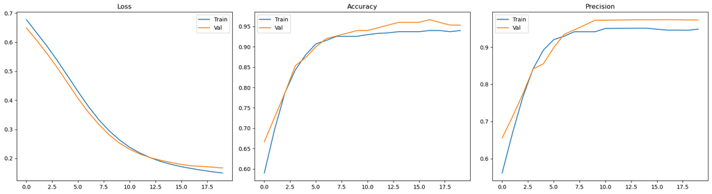

```python
plot_history(history)
```

### 6.5. Early Stopping

Let's implement Early Stopping.

```python
def train_model(
    model, train_loader, val_loader,
    criterion, optimizer, device,
    metrics,
    early_stopping_patience=10,  # New
    epochs=10
):
    metric_names = list(metrics.keys())
    logger = TrainingLogger(metric_names)

    best_val_loss = float('inf')
    epochs_no_improve = 0
    best_model_state = None

    for epoch in range(1, epochs + 1):
        train_loss, train_metrics = train_one_epoch(model, train_loader, criterion, optimizer, device, metrics)
        val_loss, val_metrics = validate_one_epoch(model, val_loader, criterion, device, metrics)

        # Logging
        logger.log_epoch(train_loss, val_loss, train_metrics, val_metrics)
        logger.print_epoch(epoch)

        # Early Stopping
        if early_stopping_patience is not None:
            if val_loss < best_val_loss:
                best_val_loss = val_loss
                epochs_no_improve = 0
                best_model_state = model.state_dict()  # Save best model state
            else:
                epochs_no_improve += 1
                if epochs_no_improve >= early_stopping_patience:
                    print(f"Early stopping triggered at epoch {epoch}.")
                    if best_model_state is not None:
                        model.load_state_dict(best_model_state)  # Restore best model
                    break

    return model, logger.history
```

```python
model = BinaryClassifier().to(device)
criterion = torch.nn.CrossEntropyLoss()
optimizer = torch.optim.Adam(model.parameters(), lr=0.001)

# Run
trained_model, history = train_model(
    model, train_loader, val_loader,
    criterion, optimizer, device,
    metrics=metrics,
    early_stopping_patience=3,
    epochs=50,
)
```

```
Epoch 01 | Train Loss: 0.7449 loss: 0.7449, accuracy: 0.4357, precision: 0.3372 | Val Loss: 0.7210 loss: 0.7210, accuracy: 0.4867, precision: 0.5128
Epoch 02 | Train Loss: 0.6992 loss: 0.6992, accuracy: 0.5400, precision: 0.5436 | Val Loss: 0.6821 loss: 0.6821, accuracy: 0.5533, precision: 0.6341
Epoch 03 | Train Loss: 0.6598 loss: 0.6598, accuracy: 0.6457, precision: 0.6936 | Val Loss: 0.6427 loss: 0.6427, accuracy: 0.7067, precision: 0.8036
Epoch 04 | Train Loss: 0.6191 loss: 0.6191, accuracy: 0.7743, precision: 0.7987 | Val Loss: 0.5972 loss: 0.5972, accuracy: 0.8200, precision: 0.8592
Epoch 05 | Train Loss: 0.5714 loss: 0.5714, accuracy: 0.8529, precision: 0.8576 | Val Loss: 0.5458 loss: 0.5458, accuracy: 0.8667, precision: 0.8816
Epoch 06 | Train Loss: 0.5162 loss: 0.5162, accuracy: 0.8857, precision: 0.8889 | Val Loss: 0.4878 loss: 0.4878, accuracy: 0.9000, precision: 0.9091
Epoch 07 | Train Loss: 0.4569 loss: 0.4569, accuracy: 0.9129, precision: 0.9317 | Val Loss: 0.4266 loss: 0.4266, accuracy: 0.9400, precision: 0.9481
Epoch 08 | Train Loss: 0.3989 loss: 0.3989, accuracy: 0.9243, precision: 0.9441 | Val Loss: 0.3716 loss: 0.3716, accuracy: 0.9467, precision: 0.9605
Epoch 09 | Train Loss: 0.3462 loss: 0.3462, accuracy: 0.9286, precision: 0.9446 | Val Loss: 0.3235 loss: 0.3235, accuracy: 0.9533, precision: 0.9610
Epoch 10 | Train Loss: 0.3027 loss: 0.3027, accuracy: 0.9286, precision: 0.9419 | Val Loss: 0.2849 loss: 0.2849, accuracy: 0.9600, precision: 0.9737
Epoch 11 | Train Loss: 0.2680 loss: 0.2680, accuracy: 0.9329, precision: 0.9451 | Val Loss: 0.2544 loss: 0.2544, accuracy: 0.9533, precision: 0.9733
Epoch 12 | Train Loss: 0.2404 loss: 0.2404, accuracy: 0.9357, precision: 0.9482 | Val Loss: 0.2319 loss: 0.2319, accuracy: 0.9600, precision: 0.9737
Epoch 13 | Train Loss: 0.2202 loss: 0.2202, accuracy: 0.9371, precision: 0.9511 | Val Loss: 0.2147 loss: 0.2147, accuracy: 0.9533, precision: 0.9733
Epoch 14 | Train Loss: 0.2035 loss: 0.2035, accuracy: 0.9371, precision: 0.9483 | Val Loss: 0.2025 loss: 0.2025, accuracy: 0.9533, precision: 0.9733
Epoch 15 | Train Loss: 0.1910 loss: 0.1910, accuracy: 0.9386, precision: 0.9485 | Val Loss: 0.1931 loss: 0.1931, accuracy: 0.9600, precision: 0.9737
Epoch 16 | Train Loss: 0.1808 loss: 0.1808, accuracy: 0.9386, precision: 0.9485 | Val Loss: 0.1857 loss: 0.1857, accuracy: 0.9533, precision: 0.9733
Epoch 17 | Train Loss: 0.1726 loss: 0.1726, accuracy: 0.9414, precision: 0.9543 | Val Loss: 0.1802 loss: 0.1802, accuracy: 0.9533, precision: 0.9733
Epoch 18 | Train Loss: 0.1658 loss: 0.1658, accuracy: 0.9429, precision: 0.9517 | Val Loss: 0.1755 loss: 0.1755, accuracy: 0.9533, precision: 0.9733
Epoch 19 | Train Loss: 0.1595 loss: 0.1595, accuracy: 0.9429, precision: 0.9489 | Val Loss: 0.1736 loss: 0.1736, accuracy: 0.9533, precision: 0.9733
Epoch 20 | Train Loss: 0.1547 loss: 0.1547, accuracy: 0.9457, precision: 0.9547 | Val Loss: 0.1701 loss: 0.1701, accuracy: 0.9533, precision: 0.9733
Epoch 21 | Train Loss: 0.1499 loss: 0.1499, accuracy: 0.9457, precision: 0.9547 | Val Loss: 0.1682 loss: 0.1682, accuracy: 0.9533, precision: 0.9733
Epoch 22 | Train Loss: 0.1461 loss: 0.1461, accuracy: 0.9457, precision: 0.9547 | Val Loss: 0.1665 loss: 0.1665, accuracy: 0.9533, precision: 0.9733
Epoch 23 | Train Loss: 0.1425 loss: 0.1425, accuracy: 0.9471, precision: 0.9576 | Val Loss: 0.1658 loss: 0.1658, accuracy: 0.9533, precision: 0.9733
Epoch 24 | Train Loss: 0.1392 loss: 0.1392, accuracy: 0.9457, precision: 0.9547 | Val Loss: 0.1649 loss: 0.1649, accuracy: 0.9533, precision: 0.9733
Epoch 25 | Train Loss: 0.1365 loss: 0.1365, accuracy: 0.9471, precision: 0.9548 | Val Loss: 0.1624 loss: 0.1624, accuracy: 0.9533, precision: 0.9733
Epoch 26 | Train Loss: 0.1333 loss: 0.1333, accuracy: 0.9471, precision: 0.9576 | Val Loss: 0.1630 loss: 0.1630, accuracy: 0.9533, precision: 0.9733
Epoch 27 | Train Loss: 0.1311 loss: 0.1311, accuracy: 0.9500, precision: 0.9578 | Val Loss: 0.1610 loss: 0.1610, accuracy: 0.9533, precision: 0.9733
Epoch 28 | Train Loss: 0.1285 loss: 0.1285, accuracy: 0.9486, precision: 0.9550 | Val Loss: 0.1619 loss: 0.1619, accuracy: 0.9533, precision: 0.9733
Epoch 29 | Train Loss: 0.1254 loss: 0.1254, accuracy: 0.9514, precision: 0.9552 | Val Loss: 0.1617 loss: 0.1617, accuracy: 0.9533, precision: 0.9733
Epoch 30 | Train Loss: 0.1230 loss: 0.1230, accuracy: 0.9514, precision: 0.9552 | Val Loss: 0.1610 loss: 0.1610, accuracy: 0.9533, precision: 0.9733
Epoch 31 | Train Loss: 0.1211 loss: 0.1211, accuracy: 0.9529, precision: 0.9554 | Val Loss: 0.1600 loss: 0.1600, accuracy: 0.9533, precision: 0.9733
Epoch 32 | Train Loss: 0.1188 loss: 0.1188, accuracy: 0.9571, precision: 0.9585 | Val Loss: 0.1602 loss: 0.1602, accuracy: 0.9533, precision: 0.9733
Epoch 33 | Train Loss: 0.1164 loss: 0.1164, accuracy: 0.9614, precision: 0.9615 | Val Loss: 0.1595 loss: 0.1595, accuracy: 0.9533, precision: 0.9733
Epoch 34 | Train Loss: 0.1147 loss: 0.1147, accuracy: 0.9643, precision: 0.9645 | Val Loss: 0.1611 loss: 0.1611, accuracy: 0.9533, precision: 0.9733
Epoch 35 | Train Loss: 0.1126 loss: 0.1126, accuracy: 0.9629, precision: 0.9644 | Val Loss: 0.1595 loss: 0.1595, accuracy: 0.9533, precision: 0.9733
Epoch 36 | Train Loss: 0.1107 loss: 0.1107, accuracy: 0.9643, precision: 0.9645 | Val Loss: 0.1603 loss: 0.1603, accuracy: 0.9533, precision: 0.9733
Epoch 37 | Train Loss: 0.1087 loss: 0.1087, accuracy: 0.9657, precision: 0.9674 | Val Loss: 0.1603 loss: 0.1603, accuracy: 0.9533, precision: 0.9733
Epoch 38 | Train Loss: 0.1071 loss: 0.1071, accuracy: 0.9657, precision: 0.9674 | Val Loss: 0.1611 loss: 0.1611, accuracy: 0.9533, precision: 0.9733
Early stopping triggered at epoch 38.
```

We can see that Early stopping was triggered at epoch 38.

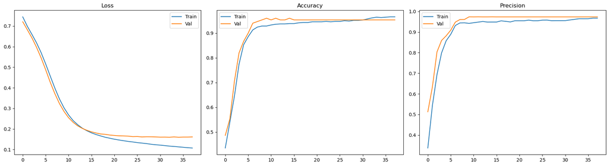

```python
plot_history(history)
```

### 6.6. Learning Rate Scheduling

```python
def train_model(
    model, train_loader, val_loader,
    criterion, optimizer, device,
    metrics,
    early_stopping_patience=None,
    scheduler=None,
    epochs=10
):

    metric_names = list(metrics.keys())
    logger = TrainingLogger(metric_names)

    best_val_loss = float('inf')
    epochs_no_improve = 0
    best_model_state = None

    for epoch in range(1, epochs + 1):
        model.train()
        train_loss, train_metrics = train_one_epoch(model, train_loader, criterion, optimizer, device, metrics)

        model.eval()
        val_loss, val_metrics = validate_one_epoch(model, val_loader, criterion, device, metrics)

        # Log training and validation results
        logger.log_epoch(train_loss, val_loss, train_metrics, val_metrics)

        # Log learning rate
        current_lr = optimizer.param_groups[0]['lr']
        print(f"Epoch {epoch}/{epochs} - LR: {current_lr:.6f}")
        logger.print_epoch(epoch)

        # Scheduler step (standard schedulers like StepLR, CosineAnnealingLR, etc.)
        if scheduler is not None:
            scheduler.step()

        # Early stopping based on val_loss
        if early_stopping_patience is not None:
            if val_loss < best_val_loss:
                best_val_loss = val_loss
                epochs_no_improve = 0
                best_model_state = model.state_dict()
                torch.save(model.state_dict(), 'best_model.pth')  # Optional
            else:
                epochs_no_improve += 1
                if epochs_no_improve >= early_stopping_patience:
                    print(f"Early stopping triggered at epoch {epoch}.")
                    if best_model_state is not None:
                        model.load_state_dict(best_model_state)
                    break

    return model, logger.history
```

```python
model = BinaryClassifier().to(device)
criterion = torch.nn.CrossEntropyLoss()
optimizer = torch.optim.Adam(model.parameters(), lr=0.01) # reduce from previous examples to prove lr scheulder


#The StepLR scheduler adjusts the learning rate every step_size epochs
scheduler = torch.optim.lr_scheduler.StepLR(optimizer, step_size=5, gamma=0.1)

# Run
trained_model, history = train_model(
    model, train_loader, val_loader,
    criterion, optimizer, device,
    metrics=metrics,
    early_stopping_patience=20,
    scheduler=scheduler,
    epochs=50,
)
```

[output not shown]

We can see that the learning rate was reduced by a factor of 10 every 5 epochs.

## Annex

### A. A reminder about val and test sets

Let's remember the purpose of the val and test sets:

|  | **Validation Set** | **Test Set** |
| --- | --- | --- |
| ✅ **Purpose** | Tune model (monitor overfitting, early stopping, etc.) | Final performance evaluation |
| 🔁 **Used During Training?** | Yes (after each epoch) | ❌ Never used during training or tuning |
| 📉 **Affects Learning?** | Yes (e.g., early stopping, LR sched) | No — used **once at the end** |
| 📌 **Best Practice** | Used for model selection | Used for final reporting only |

### B. About loss.item() and different batch sizes

```python
# Example: 3 samples, 2 classes
outputs = torch.tensor([[2.0, 1.0], [0.5, 2.5], [1.2, 0.8]])  # logits
labels = torch.tensor([0, 1, 1])  # true class indices

criterion = nn.CrossEntropyLoss()  # default: reduction='mean'
loss = criterion(outputs, labels)
print(loss.item())
```

```
0.45106831192970276
```

What's happening internally? Compute per-sample losses using the negative log likelihood after softmax:

```python
criterion = nn.CrossEntropyLoss(reduction='none')
per_sample_losses = criterion(outputs, labels)
print(per_sample_losses)  # tensor of shape [3]
```

```
tensor([0.3133, 0.1269, 0.9130])
```

```python
# then pytroch computes the avearge
loss_mean = per_sample_losses.mean()
print(loss_mean.item())  # this is what loss.item() gives you with reduction='mean'
```

```
0.45106831192970276
```

```python
# to get non average loss
criterion = nn.CrossEntropyLoss(reduction='sum')
loss = criterion(outputs, labels)
print(loss.item())  # sum of losses across the batch
```

```
1.3532049655914307
```

You only need to multiply loss.item() by the batch size if you're using a loss function with reduction='mean' and want to compute the total (summed) loss over all samples, for example, to correctly calculate an epoch-level average.

When using reduction='mean', loss.item() gives the average loss over the current batch, regardless of batch size.

To accumulate the correct total loss across an epoch where batch sizes may vary (especially the last batch), you must convert the mean back to total by multiplying:

`total_loss += loss.item() * batch_size`

then, at the end:

`avg_loss = total_loss / total_samples`

Let’s say two batches:

- Batch 1: 4 samples, loss.item() = 1.5 → total loss = 4 × 1.5 = 6.0
- Batch 2: 2 samples, loss.item() = 1.0 → total loss = 2 × 1.0 = 2.0

Total samples: 6

Epoch loss: (6.0 + 2.0) / 6 = 1.33

If you had just done:

avg = (1.5 + 1.0) / 2 = 1.25 ❌ you’d get the wrong average, because you didn’t account for the different batch sizes.

| You want... | Use... |
| --- | --- |
| Per-batch average loss | `loss.item()` |
| Total summed loss | `loss.item() * batch_size` |
| Epoch-level average (correct) | Accumulate total as above, then `/ total_samples` |

**Note:** If all batches have the same length, you don’t need to multiply by batch size, because the simple average of per-batch losses gives the correct epoch average.

❗ But if batch sizes differ? You’d get incorrect results with a simple average.

That’s why the safe, general-purpose way is always:

```
total_loss += loss.item() * batch_size
avg_loss = total_loss / total_samples
```

We can use the shortcut only if you know all batch sizes are equal (e.g., drop_last=True and dataset is divisible by batch size).

### C. Training in detail

Let's run a simple code snippet to understand what our training function does, focusing on the running and average losses.

**Setup**

- A simple linear model `y = w*x` with a known initial weight (w=1.0)
- Fake inputs and labels
- A known loss function (MSE with fixed values)
- Batch size = 2

```python
class SimpleLinearModel(nn.Module):
    def __init__(self):
        super().__init__()
        self.linear = nn.Linear(1, 1, bias=False)  # 1 weight

    def forward(self, x):
        return self.linear(x)

criterion = nn.MSELoss(reduction='mean')

inputs = torch.tensor([[1.0], [2.0], [3.0], [4.0]])
labels = torch.tensor([[2.0], [2.0], [2.0], [2.0]])

dataset = TensorDataset(inputs, labels)
dataloader = DataLoader(dataset, batch_size=2)  # batch size 2

device = torch.device("cpu")

model = SimpleLinearModel().to(device)

# known initial value
with torch.no_grad():
    model.linear.weight.fill_(1.0)  # w = 1.0

optimizer = optim.SGD(model.parameters(), lr=0.1)
```

```python
def train_one_epoch(model, dataloader, criterion, optimizer, device, metrics=None):
    model.train()
    running_loss, total_samples = 0.0, 0
    weight_after_first_batch = None

    for i, (inputs, labels) in enumerate(dataloader):
        inputs, labels = inputs.to(device), labels.to(device)
        optimizer.zero_grad()
        outputs = model(inputs)
        loss = criterion(outputs, labels)
        loss.backward()
        optimizer.step()

        batch_size = labels.size(0)
        running_loss += loss.item() * batch_size
        total_samples += batch_size

        if i == 0:
            # Capture the weight right after first batch update
            weight_after_first_batch = model.linear.weight.item()

    avg_loss = running_loss / total_samples
    return avg_loss, running_loss, weight_after_first_batch

avg_loss, rl, w_after_first = train_one_epoch(model, dataloader, criterion, optimizer, device)
print(f"Average loss: {avg_loss:.4f}")
print(f"Running loss: {rl:.4f}")
print(f"Weight after first batch update: {w_after_first:.4f}")
```

```
Average loss: 2.1125
Running loss: 8.4500
Weight after first batch update: 1.1000
```

Let's check by hand:

**Note**. We print the weight’s value after the first and only update (via gradient descent) in this simple test to understand how the calculations work later.

**Batch 1**

- Inputs: [1.0, 2.0]
- Labels: [2.0, 2.0]
- Weight: w = 1.0

Predictions (y = w*x): [1.0 × 1.0, 2.0 × 1.0] = [1.0, 2.0]

MSE: `((1.0−2.0)**2 + (2.0 - 2.0)**2)/2 = 0.5`

Running loss contribution: `MSE x batch_size = 0.5 x 2 = 1.0`

**Batch 2**

- Inputs: [3.0, 4.0]
- Labels: [2.0, 2.0]
- Weight: w = 1.1 (updated via gradient descent)

Predictions (y = w*x): [1.1 × 3.0, 1.1 × 4.0] = [3.3, 4.4]

MSE: 3.725

Running loss contribution: `MSE x batch_size = 3.725 x 2 = 7.45`

**Summary**

- Total running loss = 1.0 + 7.45 = 8.45
- Total samples: 4
- Average loss: Total running loss/Total samples = 8.45/4 = 2.1125

## References

- [PyTorch Documentation](https://docs.pytorch.org/tutorials/beginner/introyt/trainingyt.html)
- [Torchmetrics](https://lightning.ai/docs/torchmetrics/stable/)